# forcats::fct_rev()

Function of the Week

fct_rev(): Reverse factor levels

Author

Michael Daily

Published

March 5, 2025

# 1 Factor Reverse: fct_rev()

This document discusses fct_rev() and its use. fct_rev() is from the forcats package and, similar to other functions from forcats, is a tool for handling factor type variables.

```r
#load packages
library(tidyverse)
library(datasets)
library(forcats)
library(janitor)
#ChickWeight dataset
chick_wgt <-ChickWeight %>% clean_names()
glimpse(chick_wgt)
```

```
Rows: 578
Columns: 4
$ weight <dbl> 42, 51, 59, 64, 76, 93, 106, 125, 149, 171, 199, 205, 40, 49, 5…
$ time   <dbl> 0, 2, 4, 6, 8, 10, 12, 14, 16, 18, 20, 21, 0, 2, 4, 6, 8, 10, 1…
$ chick  <ord> 1, 1, 1, 1, 1, 1, 1, 1, 1, 1, 1, 1, 2, 2, 2, 2, 2, 2, 2, 2, 2, …
$ diet   <fct> 1, 1, 1, 1, 1, 1, 1, 1, 1, 1, 1, 1, 1, 1, 1, 1, 1, 1, 1, 1, 1, …
```

## 1.1 What does it do and what is it for?

### 1.1.1 What fct_rev() does:

fct_rev() does what it sounds like. It reverses the levels of the factor variable. It takes only one argument which is a factor (or character vector).

```r
#look at the levels of diet
levels(chick_wgt$diet)
```

```
[1] "1" "2" "3" "4"
```

```r
#revers the levels
levels(fct_rev(chick_wgt$diet))
```

```
[1] "4" "3" "2" "1"
```

### 1.1.2 What fct_rev() is useful for:

fct_rev() is useful for plotting factors on the y-axis. By default, the levels are plotted with the first level at the bottom and the last at the top as shown below.

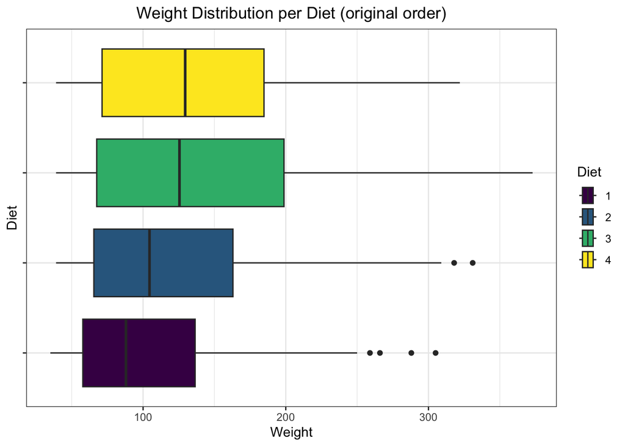

```r
ggplot(chick_wgt) +
  aes(y=diet,
      x=weight,
      fill=diet) +
  geom_boxplot() +
  scale_fill_viridis_d()+
  theme_bw()+
  theme(axis.text.y=element_blank(),
        plot.title=element_text(hjust=.5))+
  labs(y='Diet', x='Weight', fill='Diet', title='Weight Distribution per Diet (original order)')
```

fct_rev() makes it easy to plot the reverse with the first level at the top and the last level at the bottom as shown in the following figure.

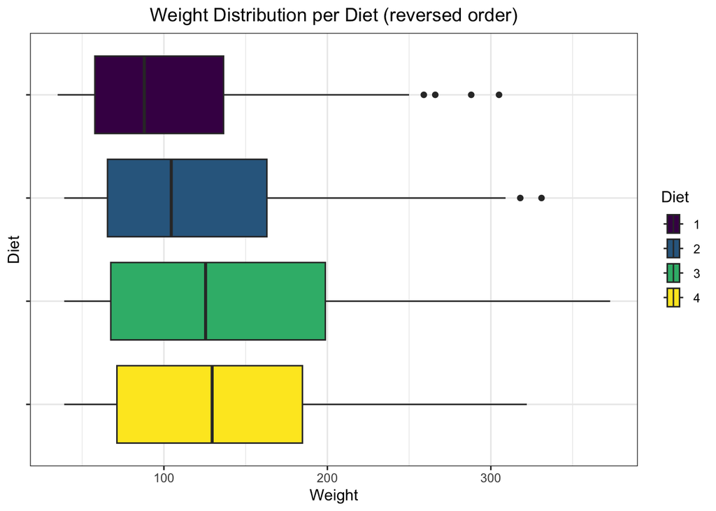

```r
ggplot(chick_wgt) +
  aes(y=fct_rev(diet),
      x=weight,
      fill=diet) +
  geom_boxplot() +
  scale_fill_viridis_d()+
  theme_bw()+
  theme(axis.text.y=element_blank(),
        plot.title=element_text(hjust=.5))+
  labs(y='Diet', x='Weight', fill='Diet', title='Weight Distribution per Diet (reversed order)')
```

## 1.2 Is it helpful?

In cases where you want to plot a factor on the y-axis, this is a helpful function; this is particularly true when the factor variable has many levels and it would be tedious to reorder by hand. Aside from reordering levels for a figure, this function seems like it would rarely, if ever, be useful.